# SemesterProject4_Evaluation

## **Importing Libraries & Data**

```python
import numpy as np
import scipy.stats as stats
import matplotlib.pyplot as plt
import math
import pandas as pd
import seaborn as sns
```

```python
#Loading the data from simple groups. The final time and coins gathered is stored in this .csv file
dataA = pd.read_csv('P4_End_Time_A.csv')
dataB = pd.read_csv('P4_End_Time_B.csv')

_specialA = pd.read_csv("special_coins_A.csv")
_specialB = pd.read_csv("special_coins_B.csv")
```

## **Describing date (Mean)**

```python
#Calculating the mean for each group.
print("Group A: ")
print(dataA.describe())
print()
print("GrouP B: ")
print(dataB.describe())
```

```
Group A:
            time      coin  playperweek
count    9.00000  9.000000     9.000000
mean   454.00000  6.222222     5.555556
std    199.51817  1.481366     1.943651
min    175.00000  5.000000     1.000000
25%    338.00000  5.000000     6.000000
50%    422.00000  5.000000     6.000000
75%    602.00000  8.000000     7.000000
max    703.00000  8.000000     7.000000

GrouP B:
             time      coin  playperweek
count    9.000000  9.000000     9.000000
mean   557.888889  6.222222     5.333333
std    199.657484  1.301708     2.121320
min    369.000000  5.000000     1.000000
25%    413.000000  5.000000     5.000000
50%    493.000000  6.000000     6.000000
75%    690.000000  7.000000     7.000000
max    990.000000  8.000000     7.000000
```

## **Median**

```python
#Calculating the median for each group

print("Group A: - Median")
print(np.median(dataA.time))
print(np.median(dataA.coin))
print(np.median(dataA.playperweek))
print("Group B: - Median")
print(np.median(dataB.time))
print(np.median(dataB.coin))
print(np.median(dataB.playperweek))
```

```
Group A: - Median
422.0
5.0
6.0
Group B: - Median
493.0
6.0
6.0
```

## **Mode**

```python
#Calculating the mode for each group. Finding the most frequent value

print("Group A: - Mode")
print(stats.mode(dataA.time))
print(stats.mode(dataA.coin))
print(stats.mode(dataA.playperweek))
print("Group B: - Mode")
print(stats.mode(dataB.time))
print(stats.mode(dataB.coin))
print(stats.mode(dataB.playperweek))
```

```
Group A: - Mode
ModeResult(mode=array([175]), count=array([1]))
ModeResult(mode=array([5]), count=array([5]))
ModeResult(mode=array([6]), count=array([4]))
Group B: - Mode
ModeResult(mode=array([369]), count=array([1]))
ModeResult(mode=array([5]), count=array([4]))
ModeResult(mode=array([7]), count=array([4]))
```

## Variance

```python
#Calculating the variance for each group.
print("Group A: - Standard Deviation")
print(dataA.var())
print()

print("Group B: - Standard Deviation")
print(dataB.var())
```

```
Group A: - Standard Deviation
time           39807.500000
coin               2.194444
playperweek        3.777778
dtype: float64

Group B: - Standard Deviation
time           39863.111111
coin               1.694444
playperweek        4.500000
dtype: float64
```

## **Standard Deviation**

A low measure of Standard Deviation indicates that the data are less spread out, whereas a high value of Standard Deviation shows that the data in a set are spread apart from their mean average values. A useful property of the standard deviation is that, unlike the variance, it is expressed in the same units as the data.

This specific std function, uses 1 degrees of freedom

```python
#Calculating the std for each group.
print("Group A: - Standard Deviation")
print(dataA.std())
print()

print("Group B: - Standard Deviation")
print(dataB.std())
```

```
Group A: - Standard Deviation
time           199.518170
coin             1.481366
playperweek      1.943651
dtype: float64

Group B: - Standard Deviation
time           199.657484
coin             1.301708
playperweek      2.121320
dtype: float64
```

## **Scatterplot**

x-axis is the time spent in seconds

y-axis is the total coins gathered

Green: Group A

Red: Group B

Scatter plots show how much one variable is affected by another. The relationship between two variables is called their correlation .

Scatter plots usually consist of a large body of data. The closer the data points come when plotted to making a straight line, the higher the correlation between the two variables, or the stronger the relationship.

If the data points make a straight line going from the origin out to high x- and y-values, then the variables are said to have a positive correlation . If the line goes from a high-value on the y-axis down to a high-value on the x-axis, the variables have a negative correlation .

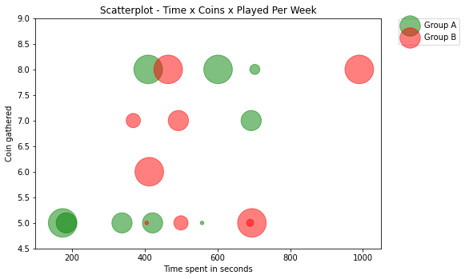

```python
s1 = [10*2**dataA.playperweek[n] for n in range(len(dataA.playperweek))]
s2 = [10*2**dataB.playperweek[m] for m in range(len(dataB.playperweek))]

fig=plt.figure()
ax=fig.add_axes([0,0,1,1])
ax.scatter(dataA.time, dataA.coin, color="green",alpha=0.5,s=s1,label="Group A")
ax.scatter(dataB.time, dataB.coin, color="red",alpha=0.5,s=s2,label="Group B")
plt.legend(bbox_to_anchor=(1.05, 1), loc='upper left', borderaxespad=0.)
ax.set_xlabel('Time spent in seconds')
ax.set_ylabel('Coin gathered')
plt.xlim(100,1050)
plt.ylim(4.50,9)
ax.set_title('Scatterplot - Time x Coins x Played Per Week')
ax.grid(False)
plt.show()
```

## **Boxplot**

A boxplot is a standardized way of displaying the distribution of data based on a five number summary (“minimum”, first quartile (Q1), median, third quartile (Q3), and “maximum”). It can tell you about your outliers and what their values are. It can also tell you if your data is symmetrical, how tightly your data is grouped, and if and how your data is skewed.

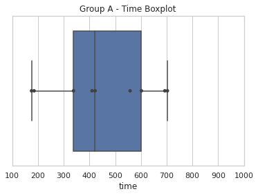

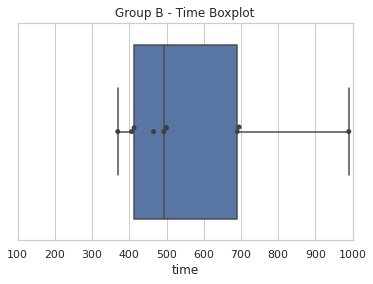

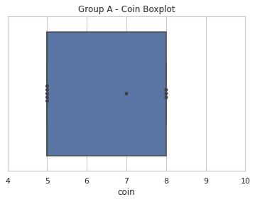

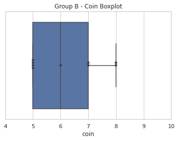

```python
sns.set_theme(style="whitegrid")
ax = sns.boxplot(x=dataA["time"])
ax = sns.swarmplot(x="time", data=dataA, color=".25")
plt.title("Group A - Time Boxplot")
plt.xlim(100,1000)
plt.show(ax)


sns.set_theme(style="whitegrid")
ax2 = sns.boxplot(x=dataB["time"])
ax2 = sns.swarmplot(x="time", data=dataB, color=".25")
plt.title("Group B - Time Boxplot")
plt.xlim(100,1000)
plt.show(ax2)

sns.set_theme(style="whitegrid")
ax3 = sns.boxplot(x=dataA["coin"])
ax3= sns.swarmplot(x="coin", data=dataA, color=".25")
plt.title("Group A - Coin Boxplot")
plt.xlim(4,10)
plt.show(ax3)

sns.set_theme(style="whitegrid")
ax4 = sns.boxplot(x=dataB["coin"])
ax4= sns.swarmplot(x="coin", data=dataB, color=".25")
plt.title("Group B - Coin Boxplot")
plt.xlim(4,10)
plt.show(ax4)
```

## **Polynomial Regression (Not sure if linear is better - ask Emil)**

```
Group A:
```

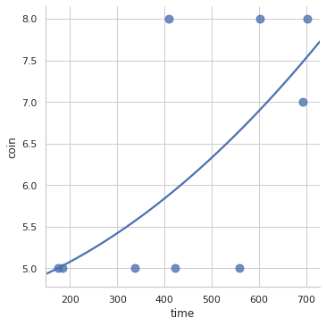

```python
#Polynomial regression fits on group A
print("Group A: ")
sns.lmplot(x="time", y="coin", data=dataA,
order=2, ci=None, scatter_kws={"s": 80},truncate=False)
```

```
Group B:
```

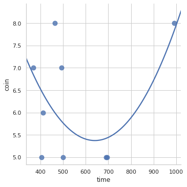

```python
#Polynomial regression fits on group B
print("Group B: ")
sns.lmplot(x="time", y="coin", data=dataB,
order=2, ci=None, scatter_kws={"s": 80},truncate=False);
```

## **Histograms**

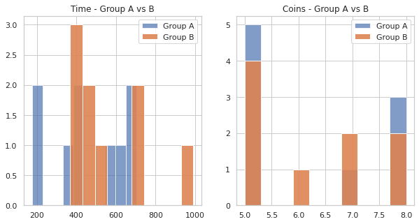

```python
fig,(axh1,axh2)= plt.subplots(1,2,figsize=(10.0, 5.0))

axh1.hist(dataA.time, bins=10,label="Group A",alpha=0.7)
axh1.hist(dataB.time, bins=10,label="Group B",alpha=0.9)
axh1.legend()




axh2.hist(dataA.coin, bins=10,label="Group A",alpha=0.7)
axh2.hist(dataB.coin, bins=10,label="Group B",alpha=0.9)
axh2.legend()

axh1.set_title('Time - Group A vs B')
axh2.set_title('Coins - Group A vs B')
```

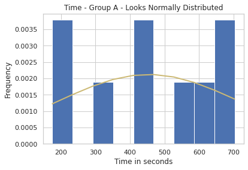

```python
count, bins, ignored = plt.hist(dataA.time, 9, density=True)
heightgauss =1/(np.std(dataA.time)* np.sqrt(2*np.pi))*np.exp(-((bins-np.mean(dataA.time))**2)/((2*np.std(dataA.time))**2))
plt.plot(bins, heightgauss, linewidth=2, color='y')
plt.xlabel("Time in seconds")
plt.ylabel("Frequency")
plt.title('Time - Group A - Looks Normally Distributed')
plt.show()
```

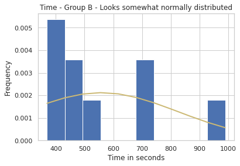

```python
count2, bins2, ignored2 = plt.hist(dataB.time, 10, density=True)
heightgauss2 =1/(np.std(dataB.time)* np.sqrt(2*np.pi))*np.exp(-((bins2-np.mean(dataB.time))**2)/((2*np.std(dataB.time))**2))
plt.plot(bins2, heightgauss2, linewidth=2, color='y')
plt.ylabel("Frequency")
plt.xlabel("Time in seconds")
plt.title('Time - Group B - Looks somewhat normally distributed')
plt.show()
```

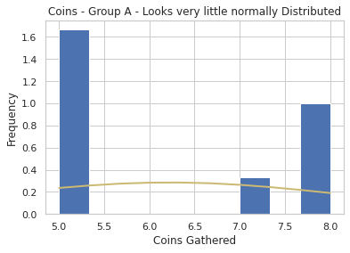

```python
count3, bins3, ignored3 = plt.hist(dataA.coin, 9, density=True)
heightgauss3 =1/(np.std(dataA.coin)* np.sqrt(2*np.pi))*np.exp(-((bins3-np.mean(dataA.coin))**2)/((2*np.std(dataA.coin))**2))
plt.plot(bins3, heightgauss3, linewidth=2, color='y')
plt.xlabel("Coins Gathered")
plt.ylabel("Frequency")
plt.title('Coins - Group A - Looks very little normally Distributed')
plt.show()
```

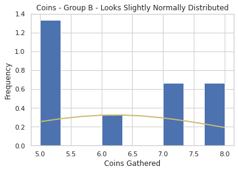

```python
count4, bins4, ignored4 = plt.hist(dataB.coin, 9, density=True)
heightgauss4 =1/(np.std(dataB.coin)* np.sqrt(2*np.pi))*np.exp(-((bins4-np.mean(dataB.coin))**2)/((2*np.std(dataB.coin))**2))
plt.plot(bins4, heightgauss4, linewidth=2, color='y')
plt.xlabel("Coins Gathered")
plt.ylabel("Frequency")
plt.title('Coins - Group B - Looks Slightly Normally Distributed')
plt.show()
```

## **Anderson-Darling - Normality Test**

```python
print(stats.anderson(dataB.time))

#Example of Anderson-Darling Test - Group A
print("Group A - Time ")
result = stats.anderson(dataA.time)

print('stat=%.3f' % (result.statistic))
for i in range(len(result.critical_values)):
 sl, cv = result.significance_level[i], result.critical_values[i]
 if result.statistic < cv:
  print('Data follows Normal at the %.1f%% level' % (sl))
 else:
  print('Data does not follows Normal at the %.1f%% level' % (sl))

print()
#Example of Anderson-Darling Test - Group B
print("Group B - Time")
result2 = stats.anderson(dataB.time)
print('stat=%.3f' % (result2.statistic))
for ii in range(len(result2.critical_values)):
 sl2, cv2 = result2.significance_level[ii], result2.critical_values[ii]
 if result2.statistic < cv2:
  print('Data follows Normal at the %.1f%% level' % (sl2))
 else:
  print('Data does not follows Normal at the %.1f%% level' % (sl2))

print()
#Example of Anderson-Darling Test - Group B
print("Group A - Coin")
result3 = stats.anderson(dataA.coin)
print('stat=%.3f' % (result3.statistic))
for iii in range(len(result3.critical_values)):
 sl23, cv23 = result3.significance_level[iii], result3.critical_values[iii]
 if result3.statistic < cv23:
  print('Data follows Normal at the %.1f%% level' % (sl23))
 else:
  print('Data does not follows Normal at the %.1f%% level' % (sl23))

print()
#Example of Anderson-Darling Test - Group B
print("Group B - Coin")
result4 = stats.anderson(dataB.coin)
print('stat=%.3f' % (result4.statistic))
for iiii in range(len(result4.critical_values)):
 sl234, cv234 = result4.significance_level[iiii], result4.critical_values[iiii]
 if result4.statistic < cv234:
  print('Data follows Normal at the %.1f%% level' % (sl234))
 else:
  print('Data does not follows Normal at the %.1f%% level' % (sl234))
```

```
AndersonResult(statistic=0.6353025262237448, critical_values=array([0.507, 0.578, 0.693, 0.808, 0.961]), significance_level=array([15. , 10. ,  5. ,  2.5,  1. ]))
Group A - Time
stat=0.275
Data follows Normal at the 15.0% level
Data follows Normal at the 10.0% level
Data follows Normal at the 5.0% level
Data follows Normal at the 2.5% level
Data follows Normal at the 1.0% level

Group B - Time
stat=0.635
Data does not follows Normal at the 15.0% level
Data does not follows Normal at the 10.0% level
Data follows Normal at the 5.0% level
Data follows Normal at the 2.5% level
Data follows Normal at the 1.0% level

Group A - Coin
stat=1.206
Data does not follows Normal at the 15.0% level
Data does not follows Normal at the 10.0% level
Data does not follows Normal at the 5.0% level
Data does not follows Normal at the 2.5% level
Data does not follows Normal at the 1.0% level

Group B - Coin
stat=0.692
Data does not follows Normal at the 15.0% level
Data does not follows Normal at the 10.0% level
Data follows Normal at the 5.0% level
Data follows Normal at the 2.5% level
Data follows Normal at the 1.0% level
```

An Anderson-Darling Test is a goodness of fit test that measures how well your data fit a specified distribution. This test is most commonly used to determine whether or not your data follow a normal distribution. This test does not need a huge amount of samples in order to work.

The null hypothesis is that the data are normally distributed; the alternative hypothesis is that the data are non-normal.

For example: The test statistic for time group A, is 0.275. We can compare this value to each critical value that corresponds to each significance level to see if the test results are significant. For example:

The critical value for α = 0.01 is 0.961 Because the test statistic (0.275) is not greater than this critical value, the results are not significant at a significance level of 0.01. The critical value for α = 0.025 is 0.808. Because the test statistic (0.275) is not greater than this critical value, the results are not significant at a significance level of 0.025.

We can see that the test results are not significant at any significance level, which means we would not reject the null hypothesis of the test. Thus, we don’t have sufficient evidence to say that the sample data is not normally distributed.

However, the coins in group A does clearly not follow a normal distribution since the test statistic is significant at all significant levels. Time group A could be normally distributed since its not significant at any significant levels.

The other groups lay around 0.600, and they are only significant at the upper most significant levels 15% and 10%.

It is therefore not possible to conlcude that the data is normally distributed, but some of it is and some of it is not.